# Report for Job [KEY:DNAm_DNAm_DiffCor__Spearman__No]

WGIA

2024-08-13 20:16:30

**You can bookmark this page to access the results later, or [download the report](http://gpu.zjwm.cc:88/wgia/public/job/DNAm_DNAm_DiffCor__Spearman__No/report.html) locally.**

*Results will be stored for 30 days.*

> WGIA is an open-access web application designed for genome-wide interaction analysis. Leveraging GPU parallel technologies, it significantly enhances computational efficiency. You can upload the SNP, DNA methylation, gene expression, or other biological data, and WGIA generates a comprehensive report within a short timeframe.

# 1. Datasets information

## 1.1 marker information

**There are total 100 DNA methylation loci (DMP) in group1 and 100 DNA methylation loci (DMP) in group2 used for interaction analysis.**

- In order to provide the fullest results as possible, WGIA provided interaction for all the DMP uploaded, with out quality control for the data.
- Note: If needed, some basic information about DMP can be used to perform quality control before uploaded the datasets, such as the missing rate.

## 1.2 sample information

**There are total of 50 samples in group1 and 50 samples in group2 used for interaction calculation.** **Note: There are no other sample information be used.**

# 2. Interaction analysis results

## 2.1 Correlation distribution

**The WGIA performed a total of 4,950 calculations between 100 DMP respectively in group1 and group2 for this job, encompassing correlation coefficients (Spearman) among all possible DMP-DMP pairs. The results for group1 and group2 are displayed below.**

> **CoMethy Diff Analysis:** Case-Control Differential Co-Methylation (CoMethy) Analysis examines variations in DNA methylation patterns between case (disease) and control (normal) groups. DNA methylation is an epigenetic modification that influences gene expression. This analysis helps identify methylation changes associated with the disease, providing insights into epigenetic mechanisms and potential biomarkers for diagnosis and treatment.  
> **Spearman:** Spearman correlation assesses the rank-order relationship between two variables, making it suitable for non-linear associations and ordinal data.

**The plot below displays the distribution of the Correlation of all the 4,950 DMP-DMP pairs (markers) separately in the group1 and group2 dataset.**

- These results can be downloaded here Correlation distribution files.

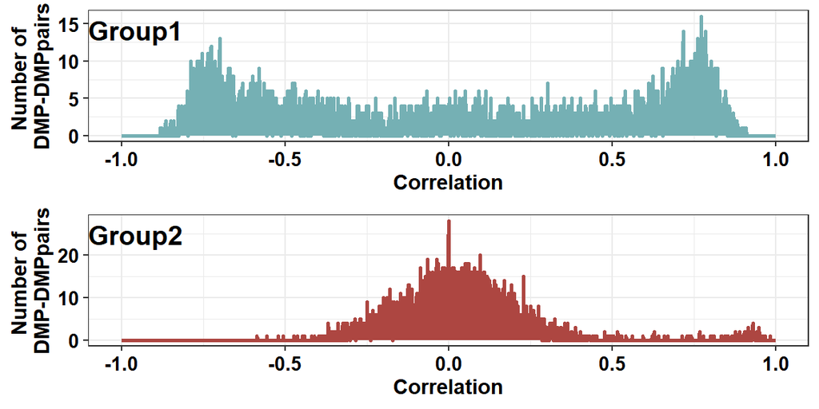

- A more rough distribution of intervals is as follows:

|  | lower_interval | upper_interval | frequent in group1 | frequent in group2 |
| --- | --- | --- | --- | --- |
| 1 | -1 | -0.8 | 70 | 0 |
| 2 | -0.8 | -0.6 | 1038 | 0 |
| 3 | -0.6 | -0.3999999999999999 | 633 | 12 |
| 4 | -0.3999999999999999 | -0.2 | 342 | 443 |
| 5 | -0.2 | 0 | 343 | 1728 |
| 6 | 0 | 0.2000000000000002 | 389 | 2093 |
| 7 | 0.2000000000000002 | 0.4000000000000001 | 329 | 518 |
| 8 | 0.4000000000000001 | 0.6000000000000001 | 459 | 40 |
| 9 | 0.6000000000000001 | 0.8 | 1103 | 19 |
| 10 | 0.8 | 1 | 231 | 82 |

## 2.2 Correlation distribution metrics

**Some basic information about the distribution is provided in the table below, including mean value, variance, standard deviation, skewness, kurtosis, median_value, lower quartile, upper quartile, interquartile range.**

- **Mean value**: The average value of the data set.
- **Variance**: A measure of how much the data points differ from the mean.
- **Standard deviation**: The square root of the variance, indicating the spread of the data.
- **Skewness**: A measure of the asymmetry of the data distribution.
- **Kurtosis**: A measure of the “tailedness” of the data distribution.
- **Median value**: The middle value that separates the higher half from the lower half of the data set.
- **Lower quartile (Q1)**: The median of the lower half of the data set (25th percentile).
- **Upper quartile (Q3)**: The median of the upper half of the data set (75th percentile).
- **Interquartile range (IQR)**: The range between the lower quartile and the upper quartile (Q3 - Q1), measuring the spread of the middle 50% of the data.
- These results can be downloaded here Correlation distribution files. The last 9 line of the file are the metric values of the distribution.

|  | metrics | value_group1 | value_group2 |
| --- | --- | --- | --- |
| 1 | mean value | 0.020481 | 0.031463 |
| 2 | variance | 0.336141 | 0.039561 |
| 3 | standard deviation | 0.579776 | 0.198899 |
| 4 | skewness | 0.001111 | 0.011165 |
| 5 | kurtosis | 0.161091 | 0.012766 |
| 6 | lower quartile | -0.570167 | -0.087563 |
| 7 | median_value | 0.019667 | 0.021867 |
| 8 | upper quartile | 0.629750 | 0.127192 |
| 9 | interquartile range | 1.199917 | 0.214755 |

- These results can be downloaded here DiffCor.txt.

  DMP-DMP pairs with significant different correlationships between two groups

  | Marker1 | Marker2 | group1_spearman | group1_lower | group1_upper | group1_t | group1_n | group1_se | group2_spearman | group2_lower | group2_upper | group2_t | group2_n | group2_se | z_test | z_pvalue |
  | --- | --- | --- | --- | --- | --- | --- | --- | --- | --- | --- | --- | --- | --- | --- | --- |
  | cg00050873 | cg00212031 | -0.414686 | -0.621320 | -0.154123 | -3.157295 | 50.00 | 0.145865 | 0.097143 | -0.186246 | 0.365609 | 0.676224 | 50.00 | 0.145865 | -2.611479 | 0.009015 |
  | cg00050873 | cg00213748 | 0.801585 | 0.673507 | 0.882934 | 9.288703 | 50.00 | 0.145865 | -0.083025 | -0.353215 | 0.199948 | -0.577208 | 50.00 | 0.145865 | 5.750544 | 8.895696e-09 |
  | cg00050873 | cg00214611 | -0.789388 | -0.875392 | -0.654945 | -8.908754 | 50.00 | 0.145865 | 0.060936 | -0.221168 | 0.333630 | 0.422966 | 50.00 | 0.145865 | -5.481839 | 4.209268e-08 |
  | cg00050873 | cg00455876 | 0.816279 | 0.696086 | 0.891965 | 9.790115 | 50.00 | 0.145865 | -0.190492 | -0.445237 | 0.092780 | -1.344386 | 50.00 | 0.145865 | 6.488183 | 8.687798e-11 |
  | cg00050873 | cg01707559 | -0.759328 | -0.856624 | -0.609880 | -8.084691 | 50.00 | 0.145865 | -0.164754 | -0.423677 | 0.119059 | -1.157263 | 50.00 | 0.145865 | -4.015605 | 0.000059 |
  | cg00050873 | cg02004872 | -0.858439 | -0.917546 | -0.762218 | -11.595376 | 50.00 | 0.145865 | -0.152269 | -0.413112 | 0.131664 | -1.067397 | 50.00 | 0.145865 | -5.496881 | 3.865674e-08 |

- If you need the full results, Please perform the interaction analysis with our local software WGIA.exe